# Data 621 Homework 4

Critical Thinking Group 3: Vyannna Hill, Jose Rodriguez, and Christian Uriostegui

2023-12-02

### Data Exploration

This assignment is a exploration of the insurance data set. The tasks are finding the optimal models for predicting if the insured driver will be involved in a car crash and estimating the value of the insurance payout.

#### Looking into the insurance data set

Reviewing the data set below, there are 8,161 insured drivers apart of the data set. There are a few categorical variables: Parent1, Mstat, Sex, education, Job, cartype, caruse, redcar, revoked, and urbancity.

For the modeling, we will need these categorical variables to be numeric to run in our model. Let’s review which variables can be updated into binary and which will need new multiple columns for dummy variables. It is noted that education, Job, and Car Type have multiple options so its dummy variables will be k-1.

In addition, there will need to be some transformations of a few non categorical variables. The values income, home val, blue book, and old claim will need to be re-define as numeric values for the regression.

```
##      INDEX        TARGET_FLAG       TARGET_AMT        KIDSDRIV
##  Min.   :    1   Min.   :0.0000   Min.   :     0   Min.   :0.0000
##  1st Qu.: 2559   1st Qu.:0.0000   1st Qu.:     0   1st Qu.:0.0000
##  Median : 5133   Median :0.0000   Median :     0   Median :0.0000
##  Mean   : 5152   Mean   :0.2638   Mean   :  1504   Mean   :0.1711
##  3rd Qu.: 7745   3rd Qu.:1.0000   3rd Qu.:  1036   3rd Qu.:0.0000
##  Max.   :10302   Max.   :1.0000   Max.   :107586   Max.   :4.0000
##
##       AGE           HOMEKIDS           YOJ          INCOME
##  Min.   :16.00   Min.   :0.0000   Min.   : 0.0   Length:8161
##  1st Qu.:39.00   1st Qu.:0.0000   1st Qu.: 9.0   Class :character
##  Median :45.00   Median :0.0000   Median :11.0   Mode  :character
##  Mean   :44.79   Mean   :0.7212   Mean   :10.5
##  3rd Qu.:51.00   3rd Qu.:1.0000   3rd Qu.:13.0
##  Max.   :81.00   Max.   :5.0000   Max.   :23.0
##  NA's   :6                        NA's   :454
##    PARENT1            HOME_VAL           MSTATUS              SEX
##  Length:8161        Length:8161        Length:8161        Length:8161
##  Class :character   Class :character   Class :character   Class :character
##  Mode  :character   Mode  :character   Mode  :character   Mode  :character
##
##
##
##
##   EDUCATION             JOB               TRAVTIME        CAR_USE
##  Length:8161        Length:8161        Min.   :  5.00   Length:8161
##  Class :character   Class :character   1st Qu.: 22.00   Class :character
##  Mode  :character   Mode  :character   Median : 33.00   Mode  :character
##                                        Mean   : 33.49
##                                        3rd Qu.: 44.00
##                                        Max.   :142.00
##
##    BLUEBOOK              TIF           CAR_TYPE           RED_CAR
##  Length:8161        Min.   : 1.000   Length:8161        Length:8161
##  Class :character   1st Qu.: 1.000   Class :character   Class :character
##  Mode  :character   Median : 4.000   Mode  :character   Mode  :character
##                     Mean   : 5.351
##                     3rd Qu.: 7.000
##                     Max.   :25.000
##
##    OLDCLAIM            CLM_FREQ        REVOKED             MVR_PTS
##  Length:8161        Min.   :0.0000   Length:8161        Min.   : 0.000
##  Class :character   1st Qu.:0.0000   Class :character   1st Qu.: 0.000
##  Mode  :character   Median :0.0000   Mode  :character   Median : 1.000
##                     Mean   :0.7986                      Mean   : 1.696
##                     3rd Qu.:2.0000                      3rd Qu.: 3.000
##                     Max.   :5.0000                      Max.   :13.000
##
##     CAR_AGE        URBANICITY
##  Min.   :-3.000   Length:8161
##  1st Qu.: 1.000   Class :character
##  Median : 8.000   Mode  :character
##  Mean   : 8.328
##  3rd Qu.:12.000
##  Max.   :28.000
##  NA's   :510
```

```
## $PARENT1
## [1] "No"  "Yes"
##
## $MSTATUS
## [1] "z_No" "Yes"
##
## $SEX
## [1] "M"   "z_F"
##
## $EDUCATION
## [1] "PhD"           "z_High School" "<High School"  "Bachelors"
## [5] "Masters"
##
## $JOB
## [1] "Professional"  "z_Blue Collar" "Clerical"      "Doctor"
## [5] "Lawyer"        "Manager"       ""              "Home Maker"
## [9] "Student"
##
## $CAR_USE
## [1] "Private"    "Commercial"
##
## $CAR_TYPE
## [1] "Minivan"     "z_SUV"       "Sports Car"  "Van"         "Panel Truck"
## [6] "Pickup"
##
## $RED_CAR
## [1] "yes" "no"
##
## $REVOKED
## [1] "No"  "Yes"
##
## $URBANICITY
## [1] "Highly Urban/ Urban"   "z_Highly Rural/ Rural"
```

#### Checking for NAs and non-normal data

Besides the needed transformations above, let’s see if there are any missing values with the current data set. It is found that YOJ (Years on the Job), car age, and age have some missing values. The team will have to use imputation for those missing values.

```
##       INDEX TARGET_FLAG  TARGET_AMT    KIDSDRIV         AGE    HOMEKIDS
##           0           0           0           0           6           0
##         YOJ      INCOME     PARENT1    HOME_VAL     MSTATUS         SEX
##         454           0           0           0           0           0
##   EDUCATION         JOB    TRAVTIME     CAR_USE    BLUEBOOK         TIF
##           0           0           0           0           0           0
##    CAR_TYPE     RED_CAR    OLDCLAIM    CLM_FREQ     REVOKED     MVR_PTS
##           0           0           0           0           0           0
##     CAR_AGE  URBANICITY
##         510           0
```

Next, the examination of the predictor variables for both linear and logistic regressions. For the linear regression, the predictor variables must pass with a linear relationship with the response variable (the targeted amount) in order to create the model.

Looking at the visual representation of their relationships below, there is a lot of non normality in the predictor values. The predictor values kids Driving, kids at home, time in force, motor vehicle points, and claim frequency resemble a linear relationship.

It can be interpreted that the claim amount lessens for the variables mentioned above. One call out is there are a ton of outliers in the variables (i.e claim frequency and mvp) that will need to be checked if they are influential points. The amount of outliers seen across the features are a concern, as these points may influence the prediction model. These predictors will need a transformation to correct its non-normality or filtered out the data set

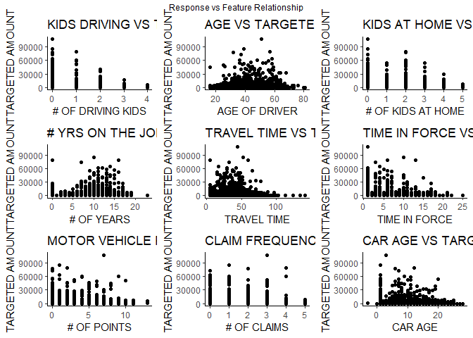

It is apparent in the density distributions plotted below the non-normalness.

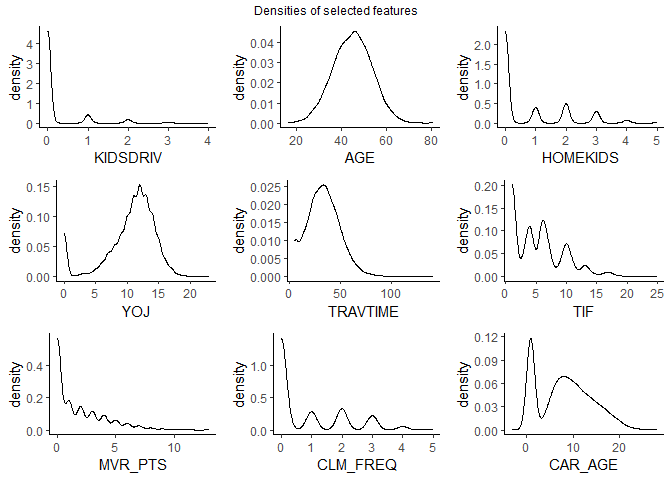

#### Looking if the data set is balanced

Before the data preparation, the team wants to look at the distribution of cases between car crashes and non crash cases. The team noticed that the distribution of cases are heavily dominated by non car crashes. This imbalance can affect how the model predicts cases where there is a car crash case. It might be the best action to down sample the training set to help with the distribution.

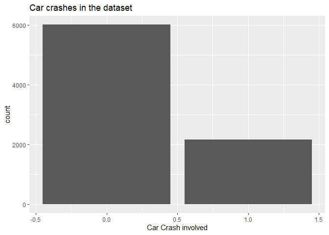

### Data Preparation

There is a list of tasks in order to begin the modeling process. The team will need to address the missing data, the categorical variables, checking column value types, and the transformations towards near normal.

#### Redefine Cost Variables

The team noticed the cost variables income, home val, blue book, and old claim pulled as categorical. Let’s transform them back into numeric values like targeted amount with the transformation below. The team did noticed after the transformation, some values of income and home value were missing. This can lead towards our second task!

#### Filling in the Missing

In the data exploration, the team noticed some missing values that will need to be filled. To avoid any bias in the imputed data, lets use MICE to impute the data. This imputation fills the missing data with the predicted value .

Now, the data set is filled with all numeric values. Let’s move onto the transformation of the categorical variables!

#### Transforms towards dummy variables

To use the categorical variables, there will need to a transformation into dummy variables. All dummy variables will take the form K-1, which K is the number of unique values in the variable. For Parents, martial status, sex, car use, red car, revoked, and urban city it’s assigning a binary true/false.

- Dictionary
  - False==0
  - True==1

Now, all the categorical variables are converted to numeric for the model!

#### Converting variables towards normal distribution

The next task is transforming the non-normal data seen in the numeric predictor values. The team wants to ensure all data is close to normal before applying to the regression model. First, Let’s check the distribution of the new spend metrics below and if they will need to be included in the transformation.

The plots suggest these predictors will need its values transform in order to use in linear regression.

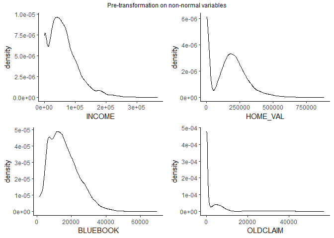

The team will use BoxCox transformations below for the following variables: INCOME, HOME_VAL, BLUEBOOK, OLDCLAIM, AGE, YOJ, MVR_PTS, CLM_FREQ, and CAR_AGE.

For reference, the transformations listed below will be used for the lambda value provided.

- Box Cox Transformations of ${\lambda}$
  - $\lambda$= -2| 1/x^2
  - $\lambda$=-1| 1/x
  - $\lambda$=-0.5| 1/sqrt(x) +$\lambda$=0| log(x) +$\lambda$=0.5| sqrt(x) +$\lambda$=1| x +$\lambda$=2| x^2

Some transformations performed needed a constant for its transformation as there are many predictors have zeros as the values provided. In order to perform the necessary transformations, a constant of 1 was applied to the needed transformation.

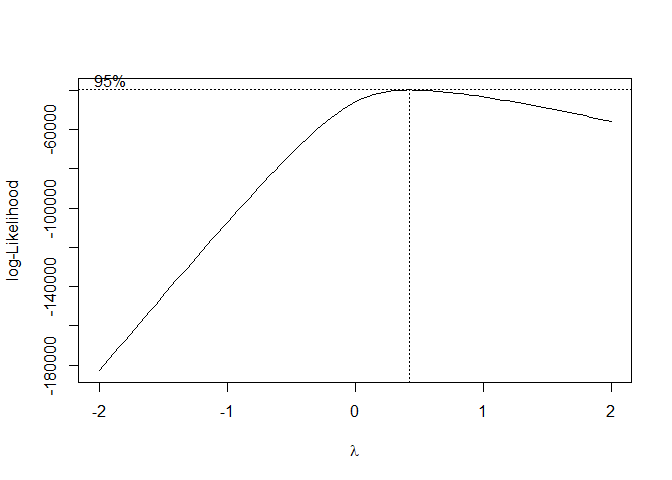

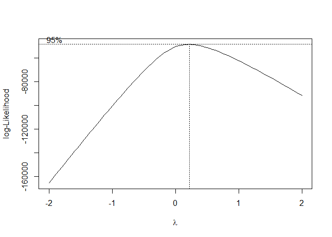

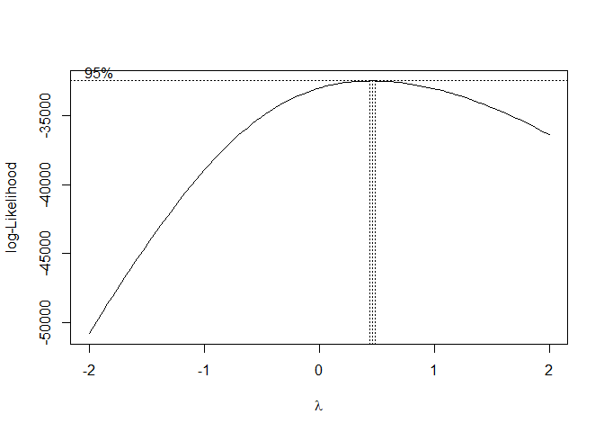

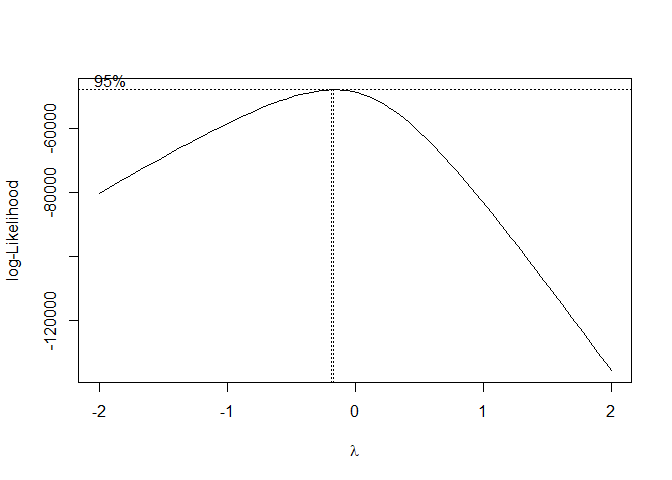

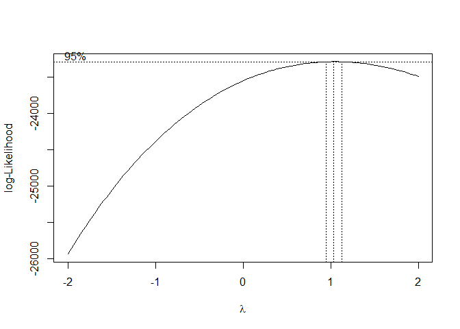

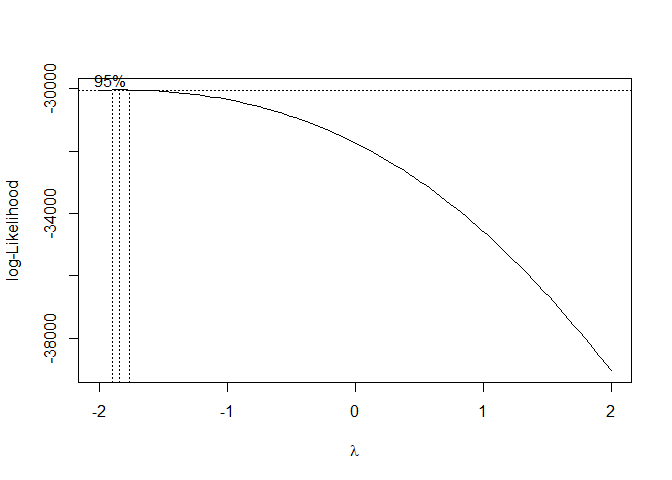

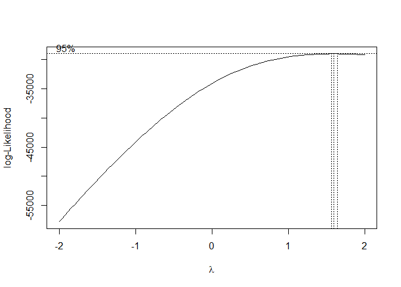

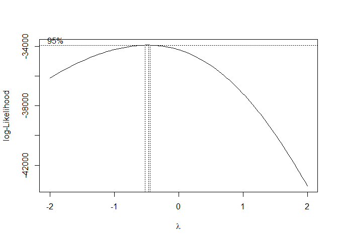

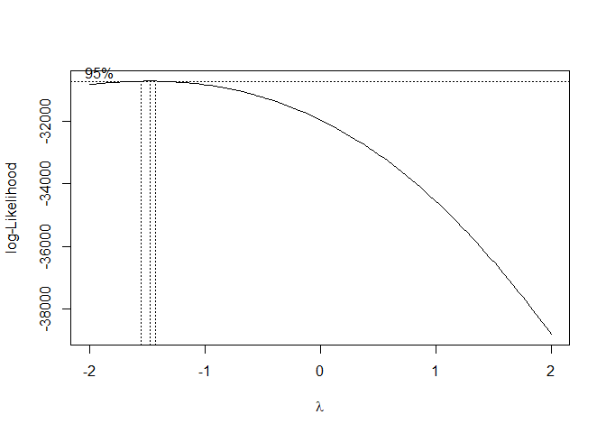

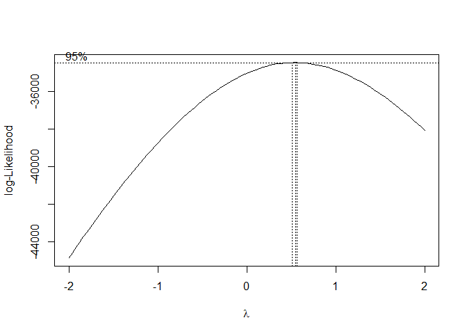

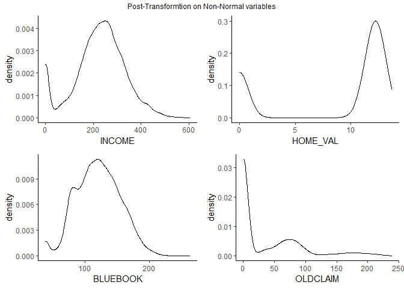

#### Checking for Multi-Collinearity

Before any steps are taken in feature selection, the current features should be check for multi-collinearity.

Looking at the correlation plot below, there aren’t any strong relationships between the variables below to remove pre feature selection.

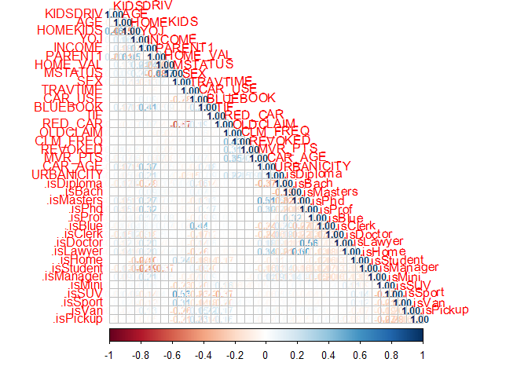

#### Assigning Factors

For the logistic model, Factoring the binary features for the model processing.

### Build Models

#### Logisitic Model Building

First it must be identified if the person was involved in a car crash. The response variable for the binary model is ‘TARGET_FLAG’. Consequently, the linear model response variable ‘TARGET_AMT’ will be removed to avoid over-fitting in the logistic binary models. A total of three logistic binary models will be built.

##### Logistic Model 1

This model includes all transformed variables along with dummy values for categorical features. It’ll be used as a baseline to compare it to other model building techniques that will be used in model 2 and model 3.

**Positive variables** As expected, the ‘URBANICITY’ variable is the highest positive coefficient for predicting a car crash. Urban cities tend to have higher traffic volume as well as more real estate development with potential to lead to more car crashes. Other variables are in line with a positive expectation such as ‘REVOKED’, ‘.isSport’, ‘CLM_FREQ’, ‘MVR_PTS’.

‘HOMEKIDS’ was a surprise. Theoretically, one would expect parents to be more likely to think about safety under the steering wheel. On the other hand, it can also be interpreted as added stress or perhaps passenger children being a potential distraction from the road. More analysis would have to be done to make a decisive conclusion.

**Negative variables** Red cars having a negative coefficient came as a surprise. It is a well known myth that red cars statistically have higher crashing rates. According to this model, that myth is debunked.

**Significant values** Several variables are **not** statistically significant. In this model ‘AGE’, ‘YOJ’, ‘SEX’, ‘REDCAR’, ‘isStudent’, ‘OLDCLAIM’, ‘CAR_AGE’, profession, and education level do not add value to the model. Its possible some are affected due to multicollinearity.

```
##
## Call:
## glm(formula = TARGET_FLAG ~ ., family = binomial, data = train.clean.binary)
##
## Deviance Residuals:
##     Min       1Q   Median       3Q      Max
## -2.4534  -0.7145  -0.4069   0.5983   3.1208
##
## Coefficients:
##               Estimate Std. Error z value Pr(>|z|)
## (Intercept) -2.754e+00  3.808e-01  -7.232 4.76e-13 ***
## KIDSDRIV     4.038e-01  6.117e-02   6.602 4.07e-11 ***
## AGE         -1.874e-03  3.648e-03  -0.514 0.607390
## HOMEKIDS     4.243e-02  3.788e-02   1.120 0.262584
## YOJ          1.982e-05  4.947e-04   0.040 0.968045
## INCOME      -2.529e-03  4.878e-04  -5.184 2.17e-07 ***
## PARENT1      3.689e-01  1.097e-01   3.364 0.000767 ***
## HOME_VAL    -2.442e-02  6.797e-03  -3.593 0.000326 ***
## MSTATUS     -5.003e-01  8.605e-02  -5.814 6.08e-09 ***
## SEX         -7.776e-02  1.106e-01  -0.703 0.482144
## TRAVTIME     1.663e-01  2.083e-02   7.983 1.43e-15 ***
## CAR_USE      7.656e-01  9.178e-02   8.342  < 2e-16 ***
## BLUEBOOK    -5.585e-03  1.214e-03  -4.602 4.18e-06 ***
## TIF         -5.553e-02  7.336e-03  -7.570 3.73e-14 ***
## RED_CAR     -1.461e-02  8.636e-02  -0.169 0.865686
## OLDCLAIM     8.063e-04  6.231e-04   1.294 0.195691
## CLM_FREQ     7.885e-03  2.156e-03   3.658 0.000255 ***
## REVOKED      6.862e-01  8.572e-02   8.005 1.19e-15 ***
## MVR_PTS      1.767e-02  1.974e-03   8.954  < 2e-16 ***
## CAR_AGE     -1.320e-04  3.800e-04  -0.347 0.728311
## URBANICITY   2.438e+00  1.123e-01  21.717  < 2e-16 ***
## .isDiploma1  5.224e-02  9.550e-02   0.547 0.584345
## .isBach1    -3.380e-01  1.133e-01  -2.984 0.002846 **
## .isMasters1 -2.386e-01  1.774e-01  -1.345 0.178476
## .isPhd1     -1.520e-01  2.098e-01  -0.724 0.468787
## .isProf1     1.979e-01  1.776e-01   1.114 0.265209
## .isBlue1     3.504e-01  1.848e-01   1.896 0.057917 .
## .isClerk1    4.196e-01  1.962e-01   2.139 0.032414 *
## .isDoctor1  -4.121e-01  2.663e-01  -1.547 0.121781
## .isLawyer1   1.331e-01  1.690e-01   0.788 0.430765
## .isHome1     1.336e-01  2.171e-01   0.616 0.538147
## .isStudent1  6.507e-04  2.246e-01   0.003 0.997688
## .isManager1 -5.374e-01  1.706e-01  -3.150 0.001635 **
## .isMini1    -5.661e-01  1.564e-01  -3.620 0.000295 ***
## .isSUV1      2.029e-01  1.914e-01   1.060 0.289100
## .isSport1    4.399e-01  2.053e-01   2.142 0.032159 *
## .isVan1      7.744e-02  1.430e-01   0.541 0.588216
## .isPickup1  -2.443e-03  1.499e-01  -0.016 0.986996
## ---
## Signif. codes:  0 '***' 0.001 '**' 0.01 '*' 0.05 '.' 0.1 ' ' 1
##
## (Dispersion parameter for binomial family taken to be 1)
##
##     Null deviance: 9415.3  on 8159  degrees of freedom
## Residual deviance: 7307.2  on 8122  degrees of freedom
## AIC: 7383.2
##
## Number of Fisher Scoring iterations: 5
```

```
##   KIDSDRIV        AGE   HOMEKIDS        YOJ     INCOME    PARENT1   HOME_VAL
##   1.348724   1.510259   2.264947   1.412259   3.129237   1.927962   1.822392
##    MSTATUS        SEX   TRAVTIME    CAR_USE   BLUEBOOK        TIF    RED_CAR
##   2.177767   3.610999   1.033886   2.453970   2.015107   1.009512   1.833973
##   OLDCLAIM   CLM_FREQ    REVOKED    MVR_PTS    CAR_AGE URBANICITY .isDiploma
##   1.440156   1.212069   1.140321   1.122624   1.961124   1.133621   2.347329
##    .isBach .isMasters     .isPhd    .isProf    .isBlue   .isClerk  .isDoctor
##   2.931604   5.639723   3.565197   4.251966   7.784217   6.175162   1.570274
##  .isLawyer    .isHome .isStudent .isManager    .isMini     .isSUV   .isSport
##   2.769606   4.114464   5.342176   2.762135   4.630472   9.126238   5.465586
##     .isVan  .isPickup
##   2.160924   4.073448
```

**Updated Model fit 1 with High VIF variables removed**

```
##
## Call:
## glm(formula = TARGET_FLAG ~ ., family = binomial, data = train.clean.binary[,
##     names.include])
##
## Deviance Residuals:
##     Min       1Q   Median       3Q      Max
## -2.4265  -0.7166  -0.4072   0.6024   3.1138
##
## Coefficients:
##               Estimate Std. Error z value Pr(>|z|)
## (Intercept) -2.146e+00  2.911e-01  -7.371 1.69e-13 ***
## KIDSDRIV     4.040e-01  6.112e-02   6.610 3.85e-11 ***
## AGE         -1.578e-03  3.628e-03  -0.435 0.663735
## HOMEKIDS     4.262e-02  3.786e-02   1.126 0.260314
## YOJ          8.137e-05  4.939e-04   0.165 0.869140
## INCOME      -2.730e-03  4.752e-04  -5.745 9.17e-09 ***
## PARENT1      3.695e-01  1.096e-01   3.372 0.000745 ***
## HOME_VAL    -2.438e-02  6.792e-03  -3.589 0.000331 ***
## MSTATUS     -5.018e-01  8.592e-02  -5.840 5.21e-09 ***
## SEX          4.655e-03  9.177e-02   0.051 0.959546
## TRAVTIME     1.668e-01  2.082e-02   8.011 1.13e-15 ***
## CAR_USE      7.223e-01  7.943e-02   9.094  < 2e-16 ***
## BLUEBOOK    -6.438e-03  1.010e-03  -6.374 1.84e-10 ***
## TIF         -5.546e-02  7.328e-03  -7.568 3.80e-14 ***
## RED_CAR     -1.739e-02  8.620e-02  -0.202 0.840082
## CLM_FREQ     8.859e-03  1.993e-03   4.445 8.80e-06 ***
## REVOKED      7.265e-01  8.039e-02   9.038  < 2e-16 ***
## MVR_PTS      1.838e-02  1.903e-03   9.656  < 2e-16 ***
## CAR_AGE     -1.118e-04  3.800e-04  -0.294 0.768517
## URBANICITY   2.440e+00  1.116e-01  21.868  < 2e-16 ***
## .isDiploma1  5.670e-02  9.458e-02   0.600 0.548834
## .isBach1    -3.538e-01  1.117e-01  -3.167 0.001543 **
## .isMasters1 -4.335e-01  1.509e-01  -2.872 0.004075 **
## .isPhd1     -3.787e-01  1.815e-01  -2.087 0.036886 *
## .isProf1    -1.199e-01  1.026e-01  -1.168 0.242850
## .isDoctor1  -5.366e-01  2.565e-01  -2.092 0.036436 *
## .isLawyer1  -3.245e-02  1.461e-01  -0.222 0.824279
## .isHome1    -2.317e-01  1.428e-01  -1.623 0.104688
## .isStudent1 -3.888e-01  1.326e-01  -2.932 0.003363 **
## .isManager1 -8.036e-01  1.170e-01  -6.866 6.61e-12 ***
## .isMini1    -6.826e-01  8.844e-02  -7.719 1.17e-14 ***
## .isSport1    2.549e-01  9.783e-02   2.606 0.009173 **
## .isVan1     -4.610e-03  1.145e-01  -0.040 0.967897
## .isPickup1  -1.238e-01  9.017e-02  -1.373 0.169707
## ---
## Signif. codes:  0 '***' 0.001 '**' 0.01 '*' 0.05 '.' 0.1 ' ' 1
##
## (Dispersion parameter for binomial family taken to be 1)
##
##     Null deviance: 9415.3  on 8159  degrees of freedom
## Residual deviance: 7315.2  on 8126  degrees of freedom
## AIC: 7383.2
##
## Number of Fisher Scoring iterations: 5
```

```
## # A tibble: 1 x 8
##   null.deviance df.null logLik   AIC   BIC deviance df.residual  nobs
##           <dbl>   <int>  <dbl> <dbl> <dbl>    <dbl>       <int> <int>
## 1         9415.    8159 -3658. 7383. 7621.    7315.        8126  8160
```

##### Logistic Model 2

This model initially includes all transformed variables along with the dummy values generated for categorical variables. The stepwise method is used, which uses a loop to remove or add variables with the best influence on the AIC score. The recursive loop terminates once all the sequential steps are executed. Ultimately, the subset with the lowest AIC value is chosen as the result. Overall, this model chose a similar subset to model fit 1 with the exception of the non-statistically significant variables.

```
##
## Call:
## glm(formula = TARGET_FLAG ~ KIDSDRIV + INCOME + PARENT1 + HOME_VAL +
##     MSTATUS + TRAVTIME + CAR_USE + BLUEBOOK + TIF + CLM_FREQ +
##     REVOKED + MVR_PTS + URBANICITY + .isBach + .isMasters + .isPhd +
##     .isBlue + .isClerk + .isDoctor + .isManager + .isMini + .isSUV +
##     .isSport, family = "binomial", data = train.clean.binary)
##
## Deviance Residuals:
##     Min       1Q   Median       3Q      Max
## -2.4708  -0.7177  -0.4077   0.5964   3.1228
##
## Coefficients:
##               Estimate Std. Error z value Pr(>|z|)
## (Intercept) -2.7107795  0.2198664 -12.329  < 2e-16 ***
## KIDSDRIV     0.4307864  0.0550240   7.829 4.91e-15 ***
## INCOME      -0.0023609  0.0003794  -6.223 4.88e-10 ***
## PARENT1      0.4466812  0.0943375   4.735 2.19e-06 ***
## HOME_VAL    -0.0224076  0.0063980  -3.502 0.000461 ***
## MSTATUS     -0.4854138  0.0803684  -6.040 1.54e-09 ***
## TRAVTIME     0.1652188  0.0207976   7.944 1.96e-15 ***
## CAR_USE      0.7374272  0.0795061   9.275  < 2e-16 ***
## BLUEBOOK    -0.0057348  0.0009860  -5.816 6.01e-09 ***
## TIF         -0.0555266  0.0073264  -7.579 3.48e-14 ***
## CLM_FREQ     0.0089288  0.0019916   4.483 7.35e-06 ***
## REVOKED      0.7312683  0.0803119   9.105  < 2e-16 ***
## MVR_PTS      0.0185250  0.0019005   9.747  < 2e-16 ***
## URBANICITY   2.4565054  0.1116330  22.005  < 2e-16 ***
## .isBach1    -0.3680445  0.0799157  -4.605 4.12e-06 ***
## .isMasters1 -0.3355855  0.1084098  -3.096 0.001965 **
## .isPhd1     -0.2934150  0.1572210  -1.866 0.062005 .
## .isBlue1     0.2382055  0.0944791   2.521 0.011694 *
## .isClerk1    0.3072306  0.0969939   3.168 0.001537 **
## .isDoctor1  -0.5026410  0.2494463  -2.015 0.043902 *
## .isManager1 -0.6607320  0.1103351  -5.988 2.12e-09 ***
## .isMini1    -0.5870978  0.0896610  -6.548 5.83e-11 ***
## .isSUV1      0.1395102  0.0840369   1.660 0.096893 .
## .isSport1    0.3762250  0.1065152   3.532 0.000412 ***
## ---
## Signif. codes:  0 '***' 0.001 '**' 0.01 '*' 0.05 '.' 0.1 ' ' 1
##
## (Dispersion parameter for binomial family taken to be 1)
##
##     Null deviance: 9415.3  on 8159  degrees of freedom
## Residual deviance: 7315.0  on 8136  degrees of freedom
## AIC: 7363
##
## Number of Fisher Scoring iterations: 5
```

##### Logistic Model 3

For model 3, the top 12 predictor variables found in model 1 and model 2 were handpicked to build a subset model. The model concludes that all the selected variables are statistically significant, however, the AIC value is higher than model 1 and model 2.

```
##
## Call:
## glm(formula = train.clean.binary[, var_subset], family = binomial)
##
## Deviance Residuals:
##     Min       1Q   Median       3Q      Max
## -2.4780  -0.7273  -0.4261   0.6364   3.0104
##
## Coefficients:
##               Estimate Std. Error z value Pr(>|z|)
## (Intercept) -2.1245610  0.1917082 -11.082  < 2e-16 ***
## URBANICITY   2.4016592  0.1107490  21.686  < 2e-16 ***
## REVOKED      0.7388683  0.0793343   9.313  < 2e-16 ***
## CAR_USE      0.7728949  0.0615070  12.566  < 2e-16 ***
## TRAVTIME     0.1615910  0.0205084   7.879 3.29e-15 ***
## TIF         -0.0540406  0.0072226  -7.482 7.31e-14 ***
## MVR_PTS      0.0204888  0.0018731  10.939  < 2e-16 ***
## .isMini1    -0.6644157  0.0728856  -9.116  < 2e-16 ***
## BLUEBOOK    -0.0072884  0.0009436  -7.724 1.12e-14 ***
## KIDSDRIV     0.5189763  0.0527051   9.847  < 2e-16 ***
## MSTATUS     -0.7592126  0.0582794 -13.027  < 2e-16 ***
## .isManager1 -0.7990406  0.1043327  -7.659 1.88e-14 ***
## INCOME      -0.0035852  0.0003023 -11.860  < 2e-16 ***
## ---
## Signif. codes:  0 '***' 0.001 '**' 0.01 '*' 0.05 '.' 0.1 ' ' 1
##
## (Dispersion parameter for binomial family taken to be 1)
##
##     Null deviance: 9415.3  on 8159  degrees of freedom
## Residual deviance: 7460.0  on 8147  degrees of freedom
## AIC: 7486
##
## Number of Fisher Scoring iterations: 5
```

```
## # A tibble: 1 x 8
##   null.deviance df.null logLik   AIC   BIC deviance df.residual  nobs
##           <dbl>   <int>  <dbl> <dbl> <dbl>    <dbl>       <int> <int>
## 1         9415.    8159 -3730. 7486. 7577.    7460.        8147  8160
```

##### Binary Model Selection

**Logistic Model Metrics Table**

```
## fitting null model for pseudo-r2
```

```
## fitting null model for pseudo-r2
```

```
## fitting null model for pseudo-r2
```

| model.build | null.deviance | df.null | logLik | AIC | BIC | deviance | df.residual | nobs | McFaddens.R2 |
| --- | --- | --- | --- | --- | --- | --- | --- | --- | --- |
| Bin model 1 | 9415.297 | 8159 | -3653.620 | 7383.240 | 7649.506 | 7307.240 | 8122 | 8160 | 0.2238970 |
| Bin model 2 | 9415.297 | 8159 | -3657.519 | 7363.039 | 7531.207 | 7315.039 | 8136 | 8160 | 0.2230687 |
| Bin model 3 | 9415.297 | 8159 | -3730.002 | 7486.003 | 7577.094 | 7460.003 | 8147 | 8160 | 0.2076720 |

**Residuals**

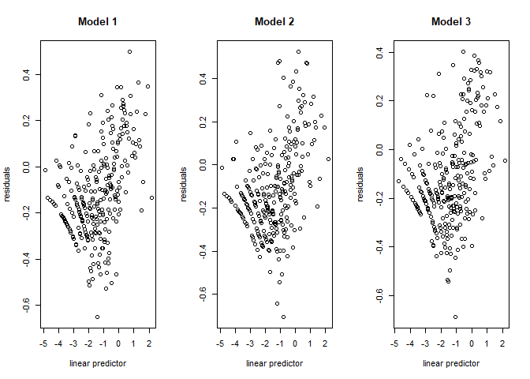

**Deviance (G^2)**  
The deviance is another measure of how well the model fits the data. Not a single model was able to reject the Null Hypothesis, therefore the deviance goodness-of-fit test confirms that all three models can be considered an adequate fit.

```
## [1] "Model 1 p-val is: 0.4979132%"
```

```
## [1] "Model 2 p-val is: 0.4979150%"
```

```
## [1] "Model 3 p-val is: 0.4979164%"
```

```r
library(performance)
#model1
performance_hosmer(fit1, n_bins = 272)
```

```
## # Hosmer-Lemeshow Goodness-of-Fit Test
##
##   Chi-squared: 292.791
##            df: 270
##       p-value:   0.163
```

```
## Summary: model seems to fit well.
```

```r
#model2
performance_hosmer(fit2, n_bins = 272)
```

```
## # Hosmer-Lemeshow Goodness-of-Fit Test
##
##   Chi-squared: 312.897
##            df: 270
##       p-value:   0.037
```

```
## Summary: model does not fit well.
```

```r
#model3
performance_hosmer(fit3, n_bins = 272)
```

```
## # Hosmer-Lemeshow Goodness-of-Fit Test
##
##   Chi-squared: 322.051
##            df: 270
##       p-value:   0.016
```

```
## Summary: model does not fit well.
```

##### Binary Model Prediction

-Crosstab of traning dataset:

| Var1 | Freq |
| --- | --- |
| 0 | 6008 |
| 1 | 2152 |

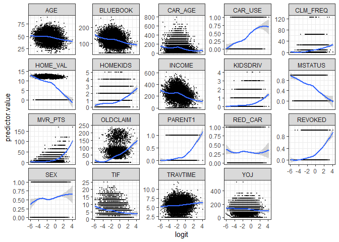

[figure not shown]

```
## [1] "Model 2 Classification Accuracy is: 79.26%"
```

```
## [1] "Model 2 Classification Error Rate is: 20.74%"
```

```
## [1] "Model 2 Precision is: 81.65%"
```

```
## [1] "Model 2 Sensitivity/Recall is: 92.66%"
```

```
## [1] "Model 2 Specificity is: 41.87%"
```

```
## [1] "Model 2 F1-score is: 86.81%"
```

```
## [1] "Model 2 AUC is: 81.21%"
```

**ROC Curve**

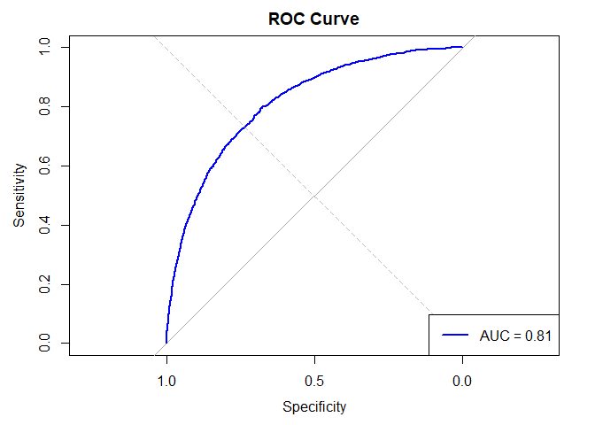

| KIDSDRIV | AGE | HOMEKIDS | YOJ | INCOME | PARENT1 | HOME_VAL | MSTATUS | SEX | TRAVTIME | CAR_USE | BLUEBOOK | TIF | RED_CAR | OLDCLAIM | CLM_FREQ | REVOKED | MVR_PTS | CAR_AGE | URBANICITY | .isDiploma | .isBach | .isMasters | .isPhd | .isProf | .isBlue | .isClerk | .isDoctor | .isLawyer | .isHome | … |
| --- | --- | --- | --- | --- | --- | --- | --- | --- | --- | --- | --- | --- | --- | --- | --- | --- | --- | --- | --- | --- | --- | --- | --- | --- | --- | --- | --- | --- | --- | --- |
| 0 | 51.41634 | 0 | 121 | 229.9609 | 0 | 0.00000 | 0 | 0 | 5.099019 | 0 | 148.22281 | 1 | 1 | 1.00000 | 0 | 0 | 4 | 100 | 1 | 0 | 1 | 0 | 0 | 0 | 0 | 0 | 0 | 0 | 0 | … |
| 1 | 42.44466 | 1 | 121 | 225.4240 | 1 | 0.00000 | 0 | 0 | 4.582576 | 0 | 137.58634 | 6 | 0 | 57.41080 | 1 | 0 | 4 | 1 | 1 | 1 | 0 | 0 | 0 | 0 | 0 | 0 | 0 | 0 | 0 | … |
| 0 | 46.92431 | 2 | 144 | 208.5354 | 1 | 0.00000 | 0 | 1 | 5.477226 | 1 | 76.81146 | 10 | 0 | 1.00000 | 0 | 0 | 0 | 100 | 0 | 1 | 0 | 0 | 0 | 0 | 1 | 0 | 0 | 0 | 0 | … |
| 0 | 36.86435 | 2 | 0 | 145.6194 | 1 | 0.00000 | 0 | 0 | 8.602325 | 0 | 96.07289 | 6 | 0 | 1.00000 | 0 | 1 | 0 | 16 | 0 | 1 | 0 | 0 | 0 | 0 | 0 | 1 | 0 | 0 | 0 | … |
| 0 | 63.82556 | 0 | 144 | 295.7381 | 0 | 0.00000 | 0 | 0 | 6.708204 | 0 | 124.17729 | 1 | 1 | 211.79707 | 8 | 0 | 16 | 1 | 1 | 1 | 0 | 0 | 0 | 0 | 0 | 0 | 0 | 0 | 0 | … |
| 0 | 49.16885 | 0 | 196 | 211.5160 | 0 | 12.24298 | 1 | 0 | 2.645751 | 1 | 160.18739 | 1 | 0 | 46.04346 | 1 | 0 | 4 | 144 | 1 | 0 | 1 | 0 | 0 | 1 | 0 | 0 | 0 | 0 | 0 | … |
| 0 | 64.95737 | 0 | 144 | 194.7845 | 0 | 12.11582 | 1 | 1 | 4.000000 | 1 | 106.25441 | 1 | 0 | 1.00000 | 0 | 0 | 0 | 1 | 1 | 1 | 0 | 0 | 0 | 0 | 1 | 0 | 0 | 0 | 0 | … |
| 0 | 58.17544 | 0 | 144 | 182.2443 | 0 | 11.97309 | 1 | 0 | 5.196152 | 1 | 154.91933 | 4 | 0 | 1.00000 | 0 | 0 | 25 | 1 | 1 | 0 | 0 | 0 | 0 | 0 | 1 | 0 | 0 | 0 | 0 | … |
| 2 | 37.97858 | 2 | 144 | 361.3046 | 1 | 12.74897 | 0 | 1 | 2.236068 | 1 | 164.92423 | 4 | 0 | 1.00000 | 0 | 0 | 0 | 81 | 0 | 0 | 1 | 0 | 0 | 0 | 1 | 0 | 0 | 0 | 0 | … |
| 0 | 53.66668 | 0 | 64 | 409.2310 | 0 | 0.00000 | 0 | 1 | 4.690416 | 0 | 184.79719 | 4 | 0 | 1.00000 | 0 | 0 | 9 | 1 | 1 | 0 | 0 | 0 | 1 | 0 | 0 | 0 | 1 | 0 | 0 | … |

| Var1 | Freq |
| --- | --- |
| 0 | 1791 |
| 1 | 350 |

#### Linear Model Building

Our goal for the linear model is to estimate the payout for those that were involved in a car crash. The variable ‘TARGET_FLAG’ will be removed to avoid over-fitting. Since we only want to look at those that have been in an accident, we’ll also need to filter out individuals who are label as not having been in an accident. Therefore, values under ‘TARGET_AMT’ that are either “0” or NA will be removed. A total of two models will be built.

##### Linear Model 1

Like the logistic model, the first model for linear model will contain all the variables. This will serve as a baseline to compare with the other models that we’ll be creating.

**Positive variables** The ‘.isPhd’ variable had the highest positive coefficient. This tells us that being a Phd student leads to a higher payout if there is an accident. If a sports car is involved in the accident, it will also lead to higher payouts. Other variables that lead to higher payouts also include ‘.Prof’, ‘.isStudent’, and ‘HOMEKIDS’.

**Negative variables**

```
##
## Call:
## lm(formula = TARGET_AMT ~ ., data = train.clean.linear)
##
## Residuals:
##    Min     1Q Median     3Q    Max
##  -8503  -3185  -1496    472  99381
##
## Coefficients:
##               Estimate Std. Error t value Pr(>|t|)
## (Intercept) -6337.1140 10823.6433  -0.585  0.55828
## KIDSDRIV     -181.5601   316.5666  -0.574  0.56635
## AGE            16.2482    19.2717   0.843  0.39926
## HOMEKIDS      206.3636   211.5307   0.976  0.32939
## YOJ             1.0952     2.8999   0.378  0.70573
## INCOME         -0.6674     2.9616  -0.225  0.82174
## PARENT1       313.2065   587.0826   0.533  0.59375
## HOME_VAL       56.6206    38.3612   1.476  0.14010
## MSTATUS      -942.2590   510.9492  -1.844  0.06530 .
## SEX         -1294.2921   646.6481  -2.002  0.04546 *
## TRAVTIME       -8.4978   121.4534  -0.070  0.94423
## CAR_USE       364.3421   521.3264   0.699  0.48471
## BLUEBOOK       29.1151     6.9101   4.213 2.62e-05 ***
## TIF           -15.7559    42.4414  -0.371  0.71050
## RED_CAR      -134.9885   496.4583  -0.272  0.78572
## OLDCLAIM        2.1743     3.5572   0.611  0.54110
## CLM_FREQ       -3.6895    11.5520  -0.319  0.74947
## REVOKED      -916.3780   461.5627  -1.985  0.04723 *
## MVR_PTS        11.6109     8.4332   1.377  0.16872
## CAR_AGE        -6.9755     2.3727  -2.940  0.00332 **
## URBANICITY     90.6472   754.1119   0.120  0.90433
## .isDiploma   -430.6307   515.3143  -0.836  0.40344
## .isBach       151.8017   625.3631   0.243  0.80823
## .isMasters   1381.6156  1086.0499   1.272  0.20346
## .isPhd       2465.4160  1288.8193   1.913  0.05589 .
## .isProf      1098.1206  1125.0530   0.976  0.32915
## .isBlue       571.8878  1139.8410   0.502  0.61591
## .isClerk      469.6616  1194.1695   0.393  0.69414
## .isDoctor   -2304.6053  1765.8633  -1.305  0.19201
## .isLawyer     354.2009  1028.0106   0.345  0.73047
## .isHome       219.5430  1292.9934   0.170  0.86519
## .isStudent    604.7964  1336.0206   0.453  0.65082
## .isManager   -786.5822  1064.6341  -0.739  0.46009
## .isMini       360.8506   920.6270   0.392  0.69513
## .isSUV       1205.0811  1107.2953   1.088  0.27658
## .isSport     1437.7792  1173.5581   1.225  0.22066
## .isVan        406.1267   831.2842   0.489  0.62521
## .isPickup     361.2560   864.2683   0.418  0.67600
## ---
## Signif. codes:  0 '***' 0.001 '**' 0.01 '*' 0.05 '.' 0.1 ' ' 1
##
## Residual standard error: 7685 on 2114 degrees of freedom
## Multiple R-squared:  0.03226,    Adjusted R-squared:  0.01532
## F-statistic: 1.905 on 37 and 2114 DF,  p-value: 0.000867
```

When looking at the residual plots, we can observe that there is linearity and homoscedasticity (constant variance of errors), however we can observe outliers, as well as a non-normal distribution of residuals as seen in the Q-Q plot.

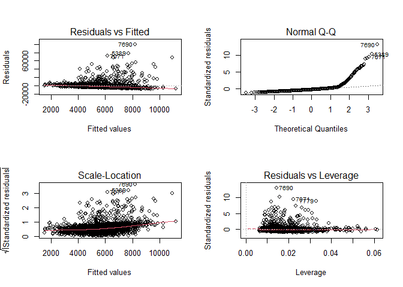

##### Model 2

Model 2 will be created using the stepwise regression technique, specifically taking a “backward” approach. It essentially starts with a full model and then iteratively removes variables that are least significant until it arrives at an optimal model.

```r
lm2 <- stats::step(lm1,direction="backward")
```

```
## Start:  AIC=38545.59
## TARGET_AMT ~ KIDSDRIV + AGE + HOMEKIDS + YOJ + INCOME + PARENT1 +
##     HOME_VAL + MSTATUS + SEX + TRAVTIME + CAR_USE + BLUEBOOK +
##     TIF + RED_CAR + OLDCLAIM + CLM_FREQ + REVOKED + MVR_PTS +
##     CAR_AGE + URBANICITY + .isDiploma + .isBach + .isMasters +
##     .isPhd + .isProf + .isBlue + .isClerk + .isDoctor + .isLawyer +
##     .isHome + .isStudent + .isManager + .isMini + .isSUV + .isSport +
##     .isVan + .isPickup
##
##              Df  Sum of Sq        RSS   AIC
## - TRAVTIME    1     289114 1.2485e+11 38544
## - URBANICITY  1     853320 1.2485e+11 38544
## - .isHome     1    1702633 1.2485e+11 38544
## - INCOME      1    2998709 1.2485e+11 38544
## - .isBach     1    3479873 1.2485e+11 38544
## - RED_CAR     1    4366188 1.2485e+11 38544
## - CLM_FREQ    1    6024125 1.2485e+11 38544
## - .isLawyer   1    7010979 1.2485e+11 38544
## - TIF         1    8139234 1.2486e+11 38544
## - YOJ         1    8422761 1.2486e+11 38544
## - .isMini     1    9073231 1.2486e+11 38544
## - .isClerk    1    9135089 1.2486e+11 38544
## - .isPickup   1   10318287 1.2486e+11 38544
## - .isStudent  1   12102263 1.2486e+11 38544
## - .isVan      1   14096085 1.2486e+11 38544
## - .isBlue     1   14866463 1.2486e+11 38544
## - PARENT1     1   16808838 1.2486e+11 38544
## - KIDSDRIV    1   19426083 1.2487e+11 38544
## - OLDCLAIM    1   22065412 1.2487e+11 38544
## - CAR_USE     1   28845212 1.2488e+11 38544
## - .isManager  1   32237549 1.2488e+11 38544
## - .isDiploma  1   41242041 1.2489e+11 38544
## - AGE         1   41980232 1.2489e+11 38544
## - HOMEKIDS    1   56207476 1.2490e+11 38545
## - .isProf     1   56263752 1.2490e+11 38545
## - .isSUV      1   69948785 1.2492e+11 38545
## - .isSport    1   88644090 1.2494e+11 38545
## - .isMasters  1   95576118 1.2494e+11 38545
## - .isDoctor   1  100589699 1.2495e+11 38545
## - MVR_PTS     1  111949354 1.2496e+11 38546
```

[output cut: 847 more lines]

```
##     MVR_PTS + CAR_AGE + .isMasters + .isPhd + .isDoctor + .isManager
##
##              Df  Sum of Sq        RSS   AIC
## <none>                     1.2546e+11 38504
## - .isDoctor   1  131007336 1.2559e+11 38504
## - HOME_VAL    1  164856391 1.2562e+11 38505
## - .isMasters  1  166799995 1.2562e+11 38505
## - MVR_PTS     1  175394197 1.2563e+11 38505
## - .isManager  1  177007130 1.2563e+11 38505
## - REVOKED     1  185278451 1.2564e+11 38505
## - SEX         1  187899477 1.2564e+11 38505
## - .isPhd      1  271956843 1.2573e+11 38507
## - MSTATUS     1  330356699 1.2579e+11 38508
## - CAR_AGE     1  446707971 1.2590e+11 38510
## - BLUEBOOK    1 1675254417 1.2713e+11 38531
```

```r
lm2<-lm(TARGET_AMT ~ HOME_VAL + MSTATUS + SEX + BLUEBOOK + REVOKED +MVR_PTS + CAR_AGE + .isPhd +.isDoctor + .isManager + .isSUV +.isSport,data = train.clean.linear)
summary(lm2)
```

```
##
## Call:
## lm(formula = TARGET_AMT ~ HOME_VAL + MSTATUS + SEX + BLUEBOOK +
##     REVOKED + MVR_PTS + CAR_AGE + .isPhd + .isDoctor + .isManager +
##     .isSUV + .isSport, data = train.clean.linear)
##
## Residuals:
##    Min     1Q Median     3Q    Max
##  -8402  -3188  -1498    426 100208
##
## Coefficients:
##              Estimate Std. Error t value Pr(>|t|)
## (Intercept)  3207.395   2161.033   1.484   0.1379
## HOME_VAL       58.317     34.163   1.707   0.0880 .
## MSTATUS      -990.868    405.289  -2.445   0.0146 *
## SEX         -1266.373    522.977  -2.421   0.0155 *
## BLUEBOOK       30.487      5.282   5.772 8.97e-09 ***
## REVOKED      -719.871    410.086  -1.755   0.0793 .
## MVR_PTS        13.976      8.037   1.739   0.0822 .
## CAR_AGE        -3.912      1.772  -2.208   0.0273 *
## .isPhd       1434.811    844.641   1.699   0.0895 .
## .isDoctor   -2510.120   1634.136  -1.536   0.1247
## .isManager  -1114.227    689.027  -1.617   0.1060
## .isSUV        801.247    567.073   1.413   0.1578
## .isSport     1082.353    663.181   1.632   0.1028
## ---
## Signif. codes:  0 '***' 0.001 '**' 0.01 '*' 0.05 '.' 0.1 ' ' 1
##
## Residual standard error: 7658 on 2139 degrees of freedom
## Multiple R-squared:  0.02757,    Adjusted R-squared:  0.02212
## F-statistic: 5.054 on 12 and 2139 DF,  p-value: 2.311e-08
```

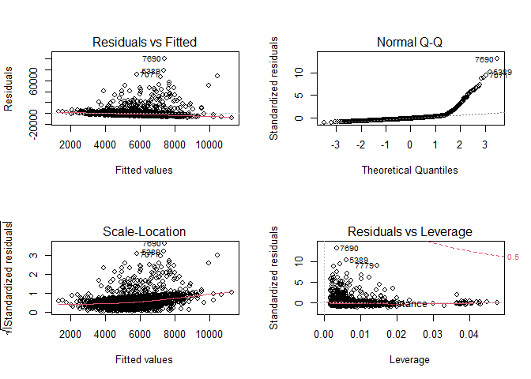

```r
par(mfrow=c(2, 2))
plot(lm2)
```